# Multinatinal Bank Customer Churn

# Chapter 1: Introduction

Customer churn, also known as customer turnover, occurs when a customer chooses to leave or unsubscribe from a service for any reason. In the context of this project, we are looking at customer churn in banking. Being able to predict customer churn is important because we want to retain as many customers as we can. (Kaemingk, 2018.)

Of course you want to keep customers, but it also is cheaper to retain your customers, than having to spend money to acquire new customers to replace the ones that left. Lower customer acquisition costs equal more profits. By identifying customers at risk of churn, we are able to identify which efforts in order to maximize their likelihood of staying. (Guliyev et al., 2021.)

We chose to analyze a multinational bank’s churn for several reasons. As an international team, we were interested in topics that spanned multiple countries, with a particular focus on either business or environment, our personal interests. When we were pitching topics, nearly every suggestion was geared towards sales or customer experience, or global environmental issues.

The aim of this project is to identify the most useful model for predicting churn churn, across three countries serviced by a multinational bank.

## Customer Analysis Overview

From our EDA in the mid term we found that more than 50% of the customer are based in France with majority of customer of average age group of 39 being in relation with bank for more than a year,51% of active customers while Male customers are predominantly higher than Female customers and also 71% of the customer uses credit card with average credit score of 650 by this analysis we found that 20% of the customer are churned,hence we decided to predict what factors are significantly affecting the customer churn in multinational bank.The model identified can then be used to inform banks of what customer activity trends and attributes should be monitored so the bank can make efforts to retain the customers before the account has been closed.

# Chapter 2: Description of the Data

This study is based on a data set that contains 10,000 observations of bank customers with 12 variables. (See below for a readout of the dataset’s structure and variable names.) Variable descriptions are as follows and we choose the data set from [Kaggle](https://www.kaggle.com/code/tamunoyedarego/abc-multinational-bank-customer-analysis) (Topre, 2022.)

```
## 'data.frame':    10000 obs. of  12 variables:
##  $ customer_id     : int  15634602 15647311 15619304 15701354 15737888 15574012 15592531 15656148 15792365 15592389 ...
##  $ credit_score    : int  619 608 502 699 850 645 822 376 501 684 ...
##  $ country         : chr  "France" "Spain" "France" "France" ...
##  $ gender          : chr  "Female" "Female" "Female" "Female" ...
##  $ age             : int  42 41 42 39 43 44 50 29 44 27 ...
##  $ tenure          : int  2 1 8 1 2 8 7 4 4 2 ...
##  $ balance         : num  0 83808 159661 0 125511 ...
##  $ products_number : int  1 1 3 2 1 2 2 4 2 1 ...
##  $ credit_card     : int  1 0 1 0 1 1 1 1 0 1 ...
##  $ active_member   : int  1 1 0 0 1 0 1 0 1 1 ...
##  $ estimated_salary: num  101349 112543 113932 93827 79084 ...
##  $ churn           : int  1 0 1 0 0 1 0 1 0 0 ...
```

1. **Customer ID** - The Unique ID of each individual customer
2. **Credit Score** - A number depicting the customer’s creditworthiness
3. **Country** - The country the customer banks from
4. **Gender** - The gender the customer identifies with
5. **Age** - The customers age
6. **Tenure** - Indicates how length in years the customer has been with the bank
7. **Balance** - The amount currently available in the customer’s account
8. **Products Number** - The number of products purchased by the customer through the bank
9. **Credit Card** - Indicates the customer has a credit card
10. **Active Member** - Indicates if the customer is an active or inactive
11. **Estimated Salary** - Bank Estimation of the income of the customer
12. **Churn** - Indicator of if the customer has left the bank or not

# Chapter 3: Independent Variables EDA Recap

#### Cleaning the Data

In preparation for exploratory data analysis, we took several steps to clean the data. We immediately dropped the customer_id variable, as we do not need the account holder’s unique identifier for our purpose. After dropping customer_id our dataset had 11 variables:

```
## 'data.frame':    10000 obs. of  11 variables:
##  $ credit_score    : int  619 608 502 699 850 645 822 376 501 684 ...
##  $ country         : chr  "France" "Spain" "France" "France" ...
##  $ gender          : chr  "Female" "Female" "Female" "Female" ...
##  $ age             : int  42 41 42 39 43 44 50 29 44 27 ...
##  $ tenure          : int  2 1 8 1 2 8 7 4 4 2 ...
##  $ balance         : num  0 83808 159661 0 125511 ...
##  $ products_number : int  1 1 3 2 1 2 2 4 2 1 ...
##  $ credit_card     : int  1 0 1 0 1 1 1 1 0 1 ...
##  $ active_member   : int  1 1 0 0 1 0 1 0 1 1 ...
##  $ estimated_salary: num  101349 112543 113932 93827 79084 ...
##  $ churn           : int  1 0 1 0 0 1 0 1 0 0 ...
```

Next, we checked for duplicate records in the data set,we found no duplicates in the data set and also checked for null variables, and 0 were found.We then converted the following variables into categorical variables:credit_card, active_member, churn, gender, tenure, product number, age.We also converted Boolean values (0,1) into character format for Credit_card (credit_card,no-credit card), active_members (Active,In Active) and churn (Churned, Retained) variables in the data set, in order to understand each variable in the data set clearly during plotting and analysis.

| credit_card | active_member | churn |
| --- | --- | --- |
| Credit Card | Active | Churned |
| No-Credit Card | Active | Retained |
| Credit Card | In Active | Churned |
| No-Credit Card | In Active | Retained |
| Credit Card | Active | Retained |
| Credit Card | In Active | Churned |

Finally, we checked our continuous variables for outliers using the outlierKD function.

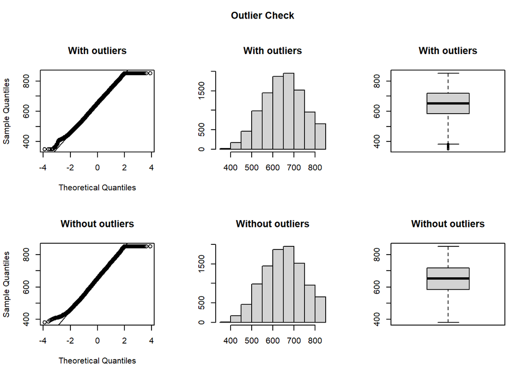

```
## Outliers identified: 15
## Proportion (%) of outliers: 0.2
## Mean of the outliers: 361
## Mean without removing outliers: 651
## Mean if we remove outliers: 651
## Outliers successfully removed
```

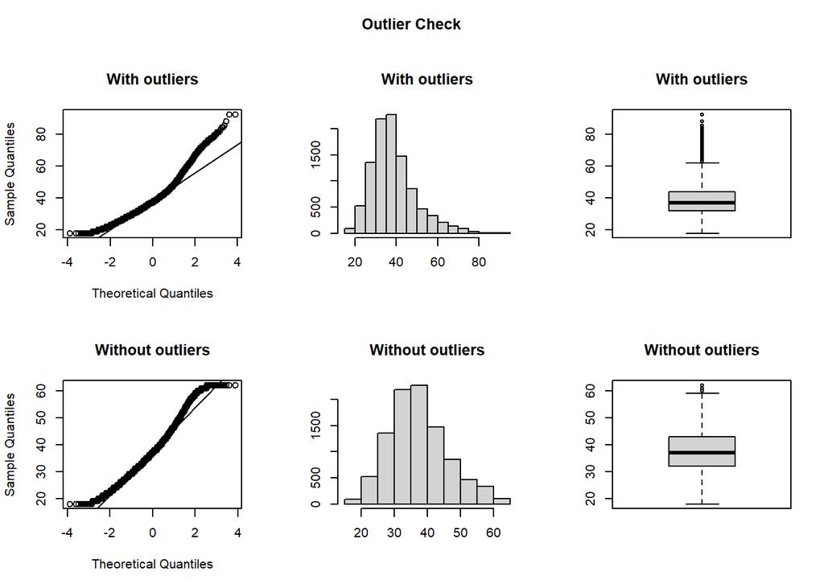

```
## Outliers identified: 359
## Proportion (%) of outliers: 3.7
## Mean of the outliers: 69.3
## Mean without removing outliers: 38.9
## Mean if we remove outliers: 37.8
## Outliers successfully removed
```

By using the outlierKD function we can observe that outliers were found only in `age` and `credit_score` variables (age: 3.7% and credit_score: 0.2%), so we decided to remove these two variables using the outlierKD function.

## Customer Analysis Review

In this section we are going to analyze each variable in the Bank churn dataset by using plots along with finding calculated mean, SD and percentages for each variable.

### What is the average credit score of the customers?

The average credit score of the customer is 650.529,most of the customers having credit score fall between 600 to 700 and standard deviation is 96.953. The below histogram shows the range of credit scores.

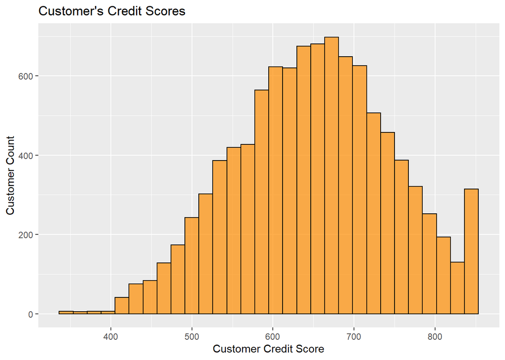

### Which are the different countries in which a customer holds a bank account?

The customers are grouped by the countries in which they have their accounts. As we see from the plot, France has more than 50% of customer accounts which is the highest among all other countries with Germany and Spain sharing equal percentages.Below, bar plot represents the number of customers in three different countries.

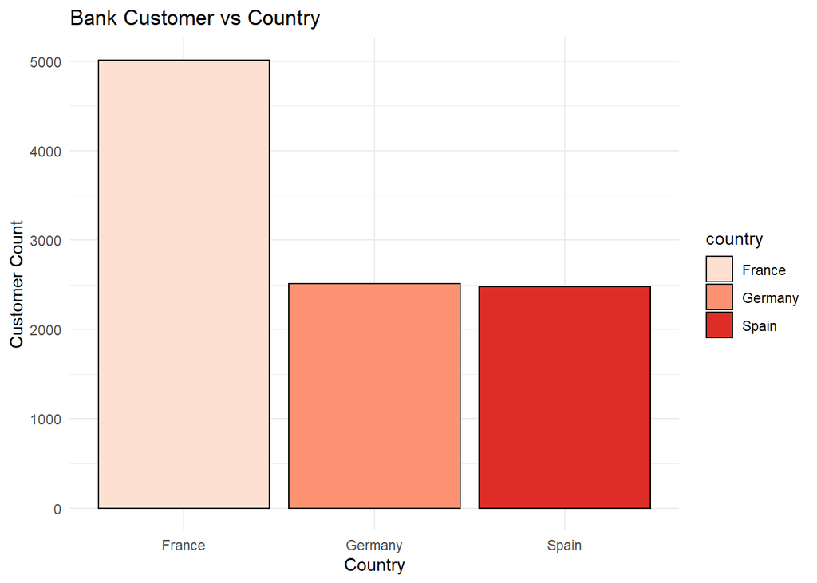

### What is the average age of the customer?

The majority of the bank customers fall below the age of 50 with average age of 39 and with standard deviation of 10.5.

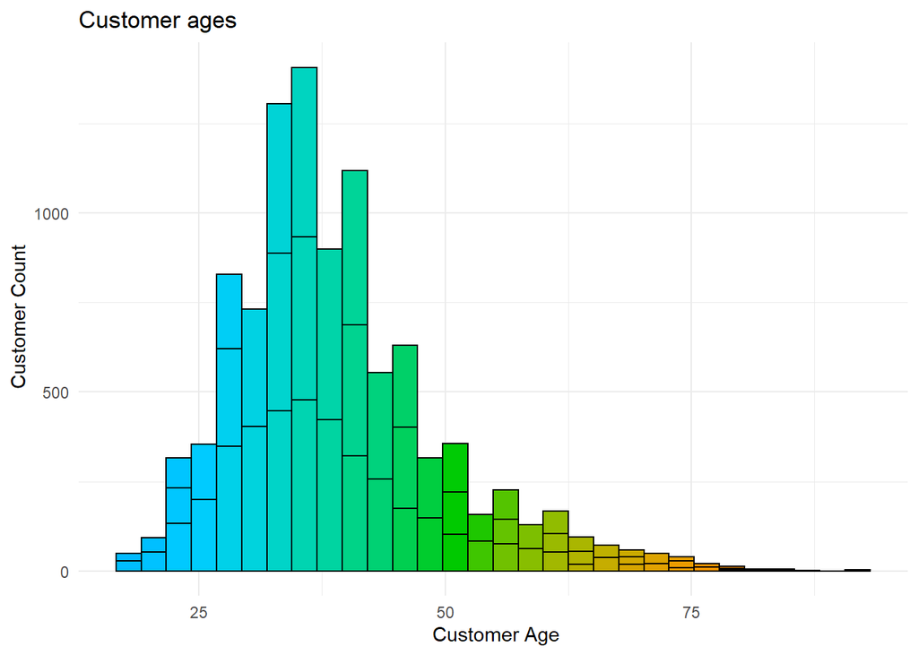

### How many years does the customer have a relationship with the bank?

Most of the customers have been with the bank for more than a year.

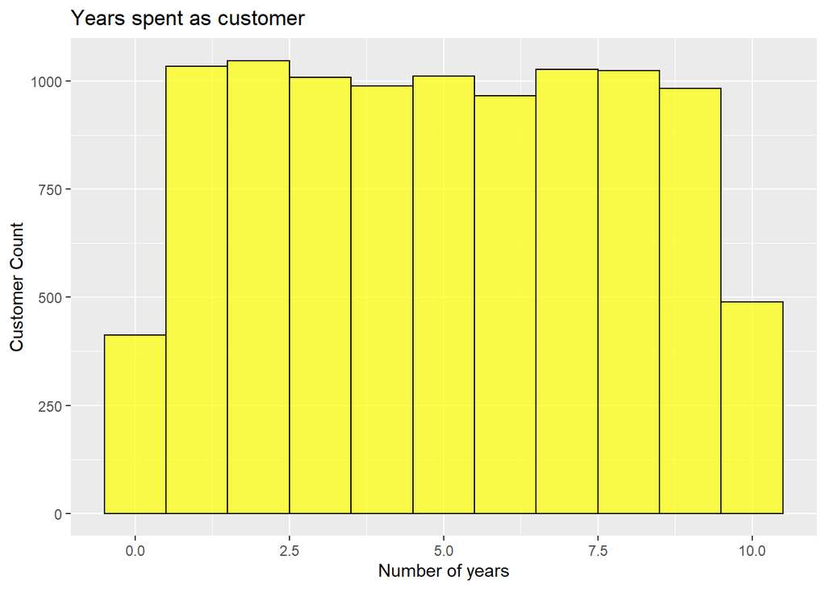

### What is the percentage of Male and Female customers who hold an account in the bank?

The bank’s customers are predominantly male which make up 55% of the customer base with the females making up the remaining 45%.

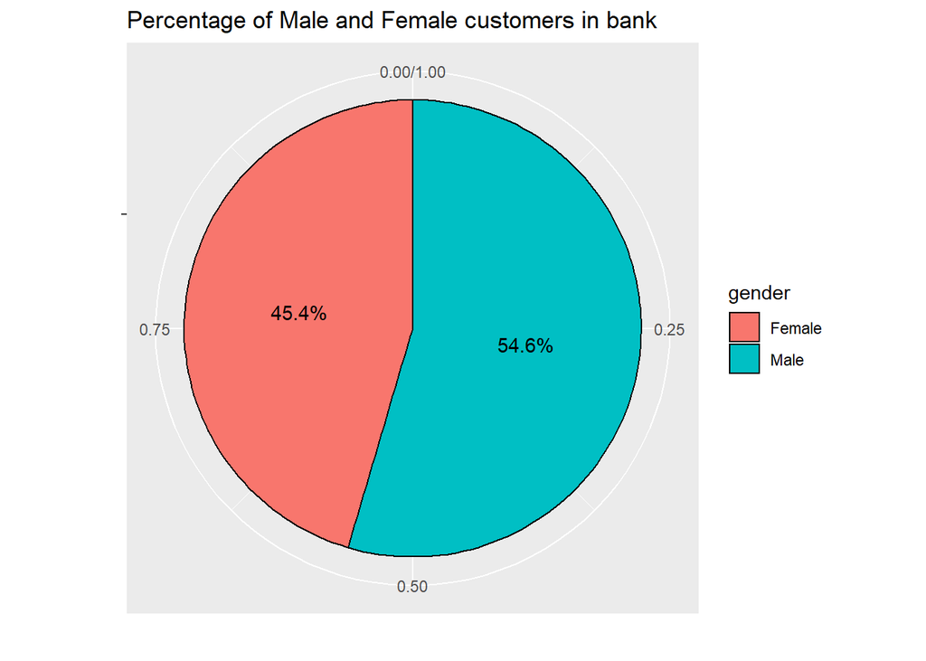

### What is the percentage of Active and Inactive account holders in the bank?

48.5% of customers are being inactive.

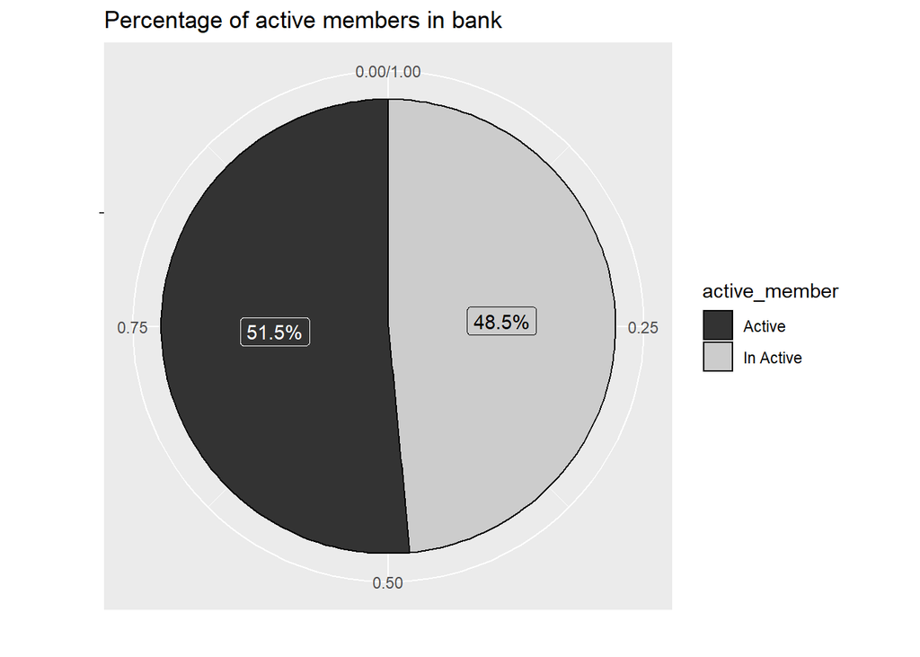

### What are the different types of services/Products purchased by customers provided by the bank for better usage of baking services?

Most of the customers use product 1 which is 50% and product 4 is the least used with 0.6%.

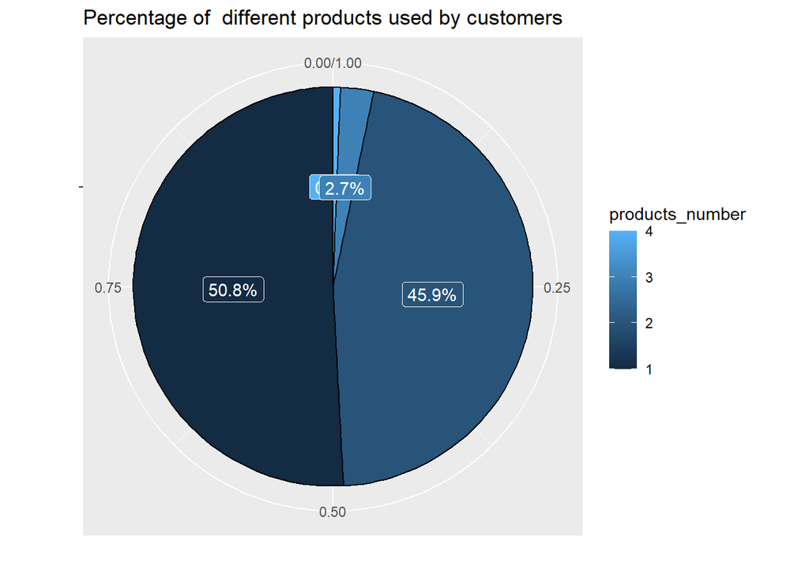

### What percentage of customers make use of credit cards?

Predominantly 71% of the Bank customers use credit card and only 29% do not.

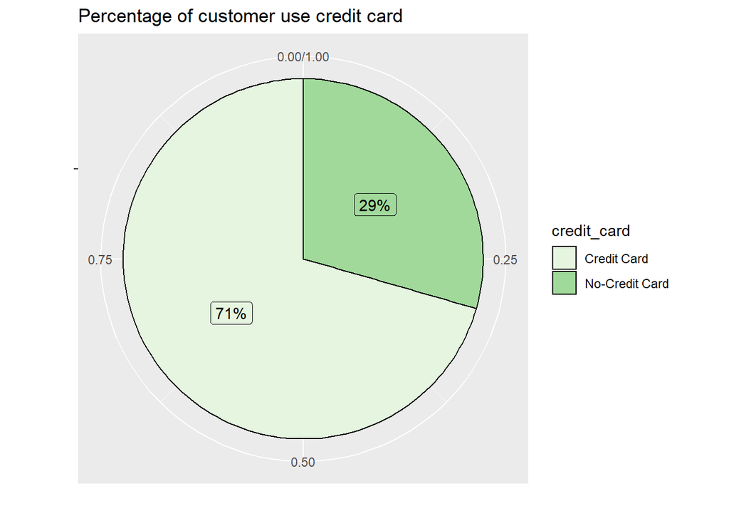

### Currently what percentage of customers are churned from the bank?

The bank managed to retain 80% of their customers with the remaining 20% where churned out.

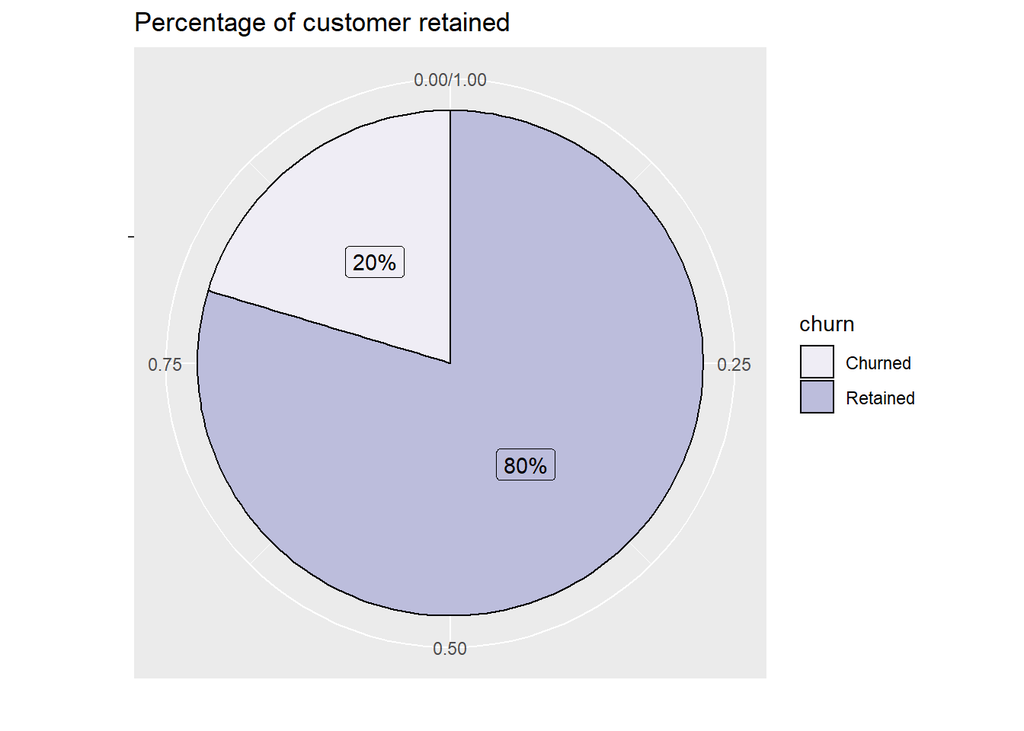

So, now the big question was what factors affected the 20% churn rate in the multinational bank across different countries. We utilized chi-squared tests, two-sample T-tests, and corrplots in order to find which factors influenced customer churn:

### Variables’ Influence on Churn

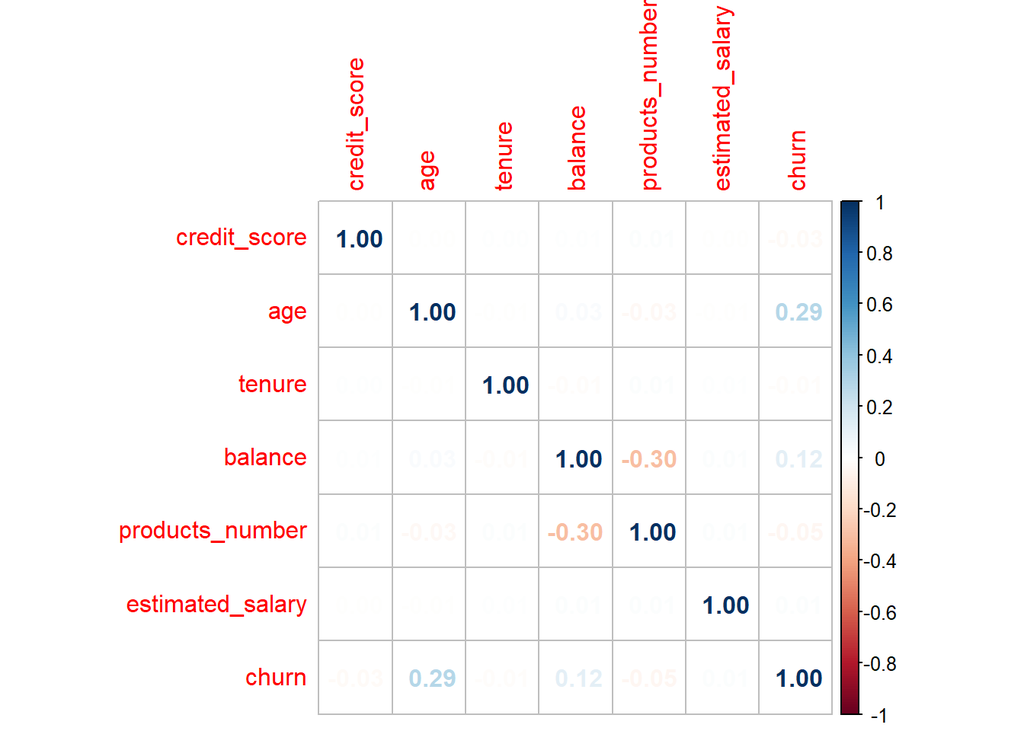

```
##
##  Pearson's product-moment correlation
##
## data:  churn_data$balance and as.numeric(churn_data$churn)
## t = 12, df = 9998, p-value <2e-16
## alternative hypothesis: true correlation is not equal to 0
## 95 percent confidence interval:
##  0.0992 0.1378
## sample estimates:
##   cor
## 0.119
```

```
## [1] 0.285
```

```
## [1] 0.272
```

```
## [1] 0.283
```

```
## [1] 0.119
```

```
## [1] 0.269
```

```
## [1] 0.119
```

# Chapter 4: Handling Imbalanced Data

In our EDA, we found out that our binary target variable, churn, was imbalanced with 7963 instances of 0/Retained customers, and 2037 instances of 1/Churned customers.

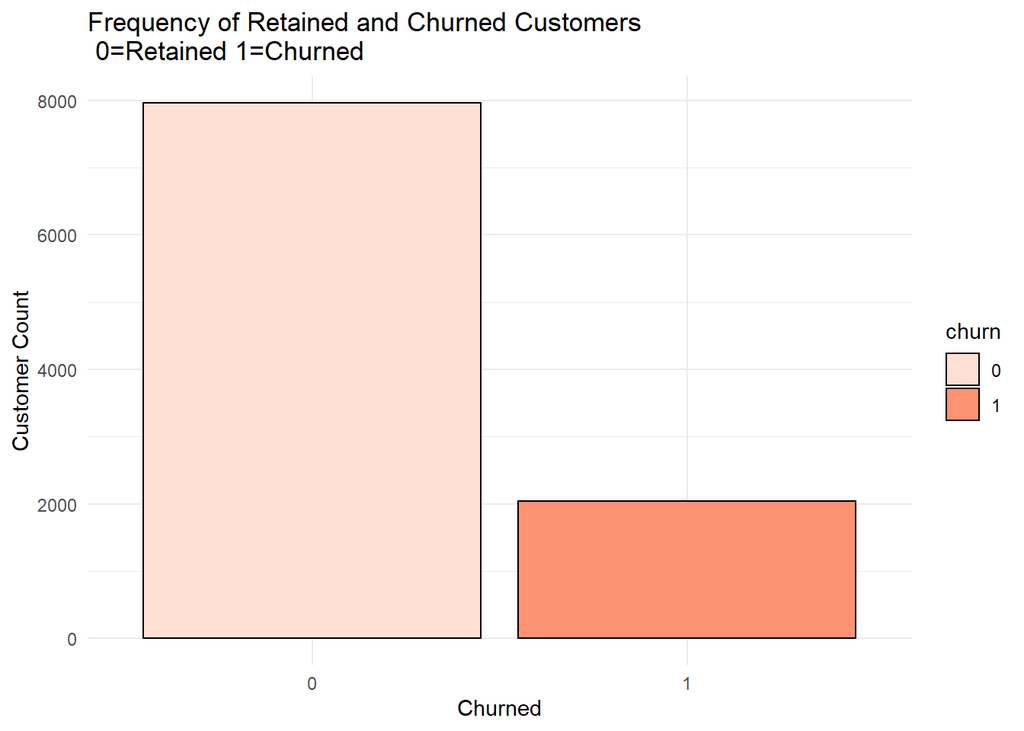

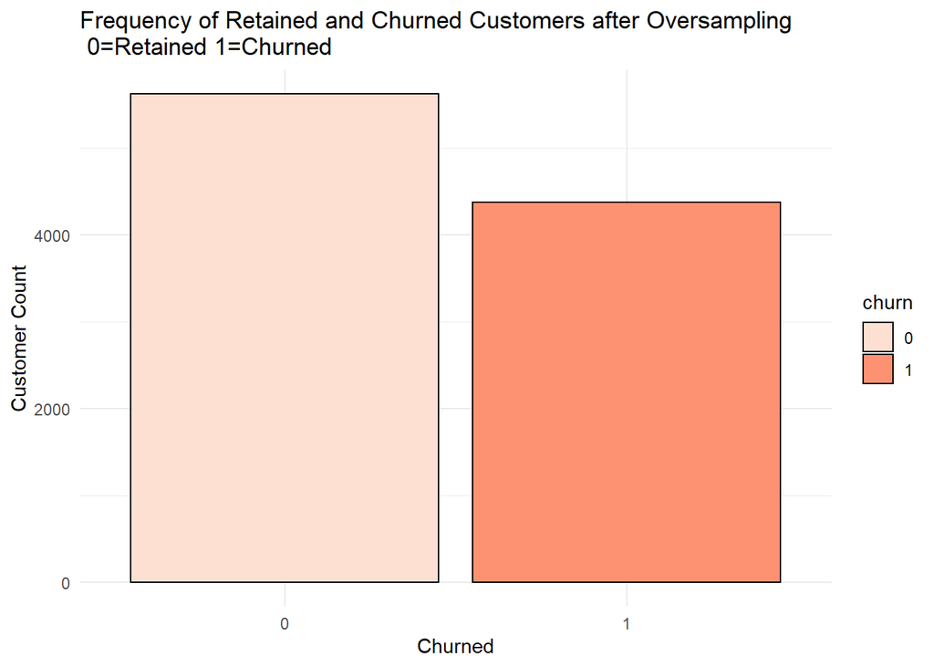

# Chapter 5: SMART QUESTIONS

## Linear Regression

### 1.Does the combination of customer demographic variables **country**, **age group**, **gender** influence the **churn rate** of the customers?

```
##
## Call:
## lm(formula = churn ~ country + age + gender, data = churn_data_pc_target)
##
## Residuals:
##    Min     1Q Median     3Q    Max
## -1.216 -0.360 -0.168  0.434  1.035
##
## Coefficients:
##                 Estimate Std. Error t value Pr(>|t|)
## (Intercept)    -0.204882   0.019500  -10.51   <2e-16 ***
## countryGermany  0.184720   0.010666   17.32   <2e-16 ***
## countrySpain   -0.011960   0.011539   -1.04      0.3
## age             0.015975   0.000441   36.24   <2e-16 ***
## genderMale     -0.106081   0.009098  -11.66   <2e-16 ***
## ---
## Signif. codes:  0 '***' 0.001 '**' 0.01 '*' 0.05 '.' 0.1 ' ' 1
##
## Residual standard error: 0.454 on 9995 degrees of freedom
## Multiple R-squared:  0.164,  Adjusted R-squared:  0.163
## F-statistic:  489 on 4 and 9995 DF,  p-value: <2e-16
```

From the results of linear regression model we observe that the variables Country$Germany,age,and Gender are highly significant.While gender is negatively impacting the customer churn but customer with certain age group and from Germany affecting the churn rate positively.

### 2.Whether the customers using **fewer products** with higher **salary**,**account balance** and **status** of the account affect the churn rate?

```
##
## Call:
## lm(formula = churn ~ products_number + estimated_salary + balance +
##     active_member, data = churn_data_pc_target)
##
## Residuals:
##    Min     1Q Median     3Q    Max
## -0.687 -0.416 -0.249  0.500  0.814
##
## Coefficients:
##                         Estimate Std. Error t value Pr(>|t|)
## (Intercept)             3.05e-01   1.78e-02   17.10  < 2e-16 ***
## products_number        -2.98e-02   7.54e-03   -3.96  7.6e-05 ***
## estimated_salary        2.43e-08   8.40e-08    0.29     0.77
## balance                 1.09e-06   8.03e-08   13.54  < 2e-16 ***
## active_memberIn Active  1.67e-01   9.69e-03   17.20  < 2e-16 ***
## ---
## Signif. codes:  0 '***' 0.001 '**' 0.01 '*' 0.05 '.' 0.1 ' ' 1
##
## Residual standard error: 0.483 on 9995 degrees of freedom
## Multiple R-squared:  0.051,  Adjusted R-squared:  0.0506
## F-statistic:  134 on 4 and 9995 DF,  p-value: <2e-16
```

From the results of linear regression model we observe that the variables account balance,account status are highly significant.while the account status impacting the customer churn negatively,but account balance is affecting positively.

## Finding the Best Model

### 3. What are the **principal components** for predicting churn rate?

Before we work on PCA, we need to ensure that the data is scaled and all the variables are either numeric or int type.

```
## 'data.frame':    10000 obs. of  11 variables:
##  $ credit_score    : int  619 608 502 699 850 645 822 376 501 684 ...
##  $ country         : chr  "France" "Spain" "France" "France" ...
##  $ gender          : chr  "Female" "Female" "Female" "Female" ...
##  $ age             : int  42 41 42 39 43 44 50 29 44 27 ...
##  $ tenure          : int  2 1 8 1 2 8 7 4 4 2 ...
##  $ balance         : num  0 83808 159661 0 125511 ...
##  $ products_number : int  1 1 3 2 1 2 2 4 2 1 ...
##  $ credit_card     : chr  "Credit Card" "No-Credit Card" "Credit Card" "No-Credit Card" ...
##  $ active_member   : chr  "Active" "Active" "In Active" "In Active" ...
##  $ estimated_salary: num  101349 112543 113932 93827 79084 ...
##  $ churn           : chr  "1" "0" "1" "0" ...
```

To perform dimenstionality reduction while preserving as much as randomness in the high dimensional space as possible.

Now we will identify correlations in the data

```
## 'data.frame':    10000 obs. of  9 variables:
##  $ country         : num  0 2 0 0 2 2 0 1 0 0 ...
##  $ gender          : num  1 1 1 1 1 0 0 1 0 0 ...
##  $ age             : int  41 39 43 27 31 24 34 25 45 24 ...
##  $ tenure          : int  1 1 2 2 6 3 10 5 3 9 ...
##  $ balance         : num  83808 0 125511 134604 102017 ...
##  $ products_number : int  1 2 1 1 2 2 2 2 2 2 ...
##  $ credit_card     : num  1 0 1 0 1 1 1 1 0 1 ...
##  $ active_member   : num  1 1 0 0 1 0 1 0 1 1 ...
##  $ estimated_salary: num  112543 93827 79084 71726 80181 ...
```

```
## [1] "Case: z-score/scaled"
```

```
## Importance of components:
##                          PC1   PC2   PC3   PC4   PC5   PC6   PC7   PC8    PC9
## Standard deviation     1.104 1.019 1.011 1.009 1.004 0.987 0.982 0.977 0.8965
## Proportion of Variance 0.135 0.115 0.114 0.113 0.112 0.108 0.107 0.106 0.0893
## Cumulative Proportion  0.135 0.251 0.364 0.477 0.589 0.698 0.805 0.911 1.0000
```

```
##                        PC1     PC2     PC3     PC4     PC5    PC6     PC7
## country           0.031631 -0.0581  0.2624 -0.2643 -0.7948 -0.277 -0.3779
## gender            0.000507  0.4144 -0.5328 -0.2147 -0.0163 -0.663  0.2374
## age               0.296251 -0.1023  0.4590 -0.0642  0.2820 -0.364  0.1984
## tenure           -0.068025 -0.3509 -0.4832  0.5049 -0.0073 -0.164 -0.4356
## balance           0.664835  0.0387 -0.1346  0.1283 -0.0636  0.127 -0.0464
## products_number  -0.673849 -0.0592  0.0956 -0.0692  0.0711 -0.036  0.0342
## credit_card      -0.047002  0.3477  0.4132  0.5223  0.1966 -0.393 -0.3245
## active_member     0.014524 -0.6654  0.0540  0.2028 -0.1357 -0.343  0.4659
## estimated_salary -0.090049  0.3502  0.0474  0.5384 -0.4715  0.186  0.4961
##                      PC8     PC9
## country          -0.0681  0.0346
## gender            0.0176  0.0460
## age              -0.6598  0.0199
## tenure           -0.4062 -0.0453
## balance           0.0961  0.7002
## products_number  -0.1382  0.7084
## credit_card       0.3659  0.0270
## active_member     0.3994  0.0224
## estimated_salary -0.2702 -0.0301
```

Correlation can vary from -1 to +1 Value close to +1 indicates a high degree of positive correlation Value close to -1 indicates a high degree of negative correlation Value close to zero or 0 indicates no correlation at all

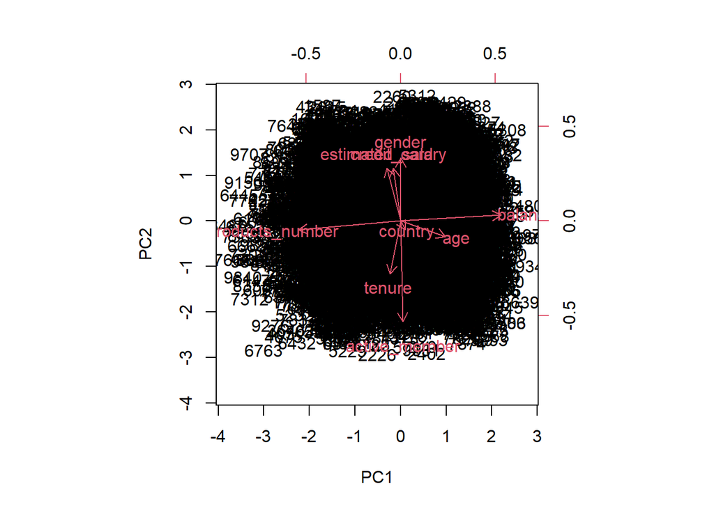

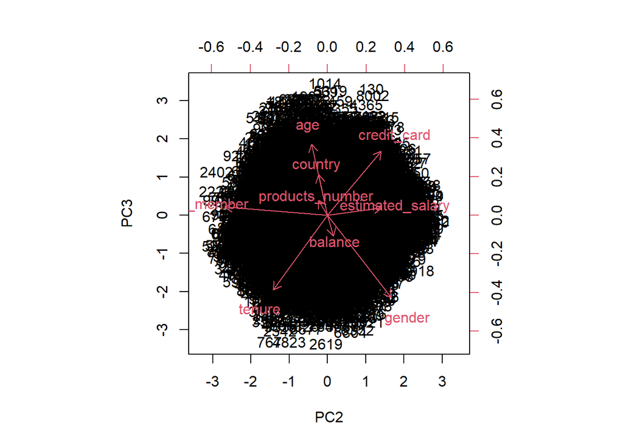

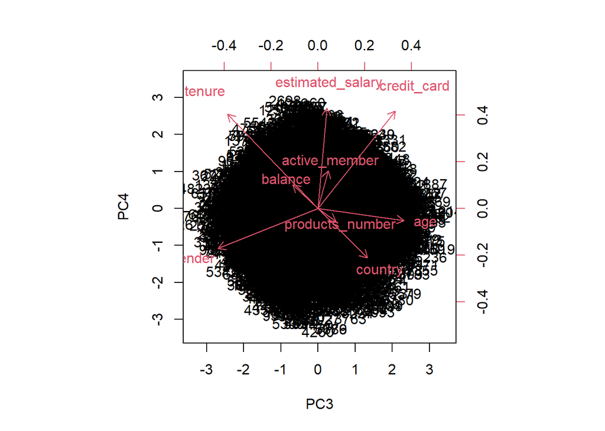

From the Biplot between PC1 and PC2 , first of all, it shows the data points plotted (projection) onto the PC1-PC2 plane, with the scales on the bottom and the left tick marks. It also shows the components on this PC1-PC2 plane, with the scales on the top and right tick marks showing the loadings.

PC1 has more variation than PC2

We have also plotted the graphs in between PC2-PC3, AND PC3-PC4: Observe that PC2 has more variation than PC3 and PC3 has more variation than PC4

Here, all components capture the majority of the variability.

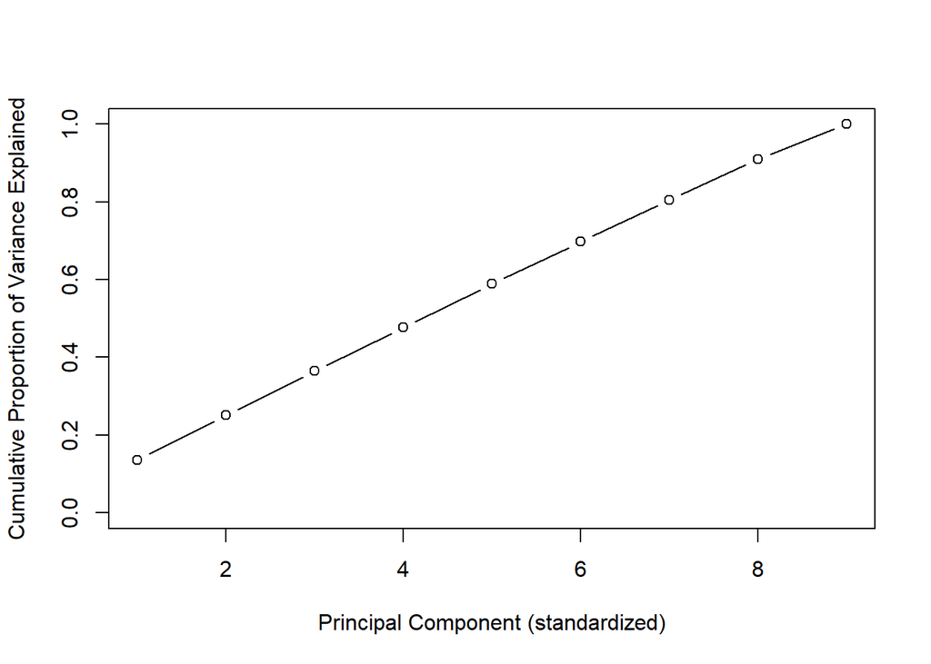